# Deep learning predicts prevalent and incident Parkinson's disease (PD)

## The goal of this project is to diagnose Parkinson's disease subjects apart from age-gender matched healthy controls under a binary classification framework.

# 1. Environment

### The PyTorch 1.7.1 in HiperGator is what I use. I imagine most other PyTorch versions will work.

#### We will download some other packages later but the base environment should do fine for the most part.

I personally use the following settings on ood hipergaor

- 2 CPU's
- 20 mem GB
- time = 12 hours (need at most 4 hours for a single experiment), 12 is flexible for a work day.
- 1 A100 GPU (hpg-ai, gpu:a100:1)

# 2. Data Acquisition and Organization

(Estimated-Time) 20 minutes to set things up

### Obviously create your own folder for the project in your own blue home-folder.

You should create the following general sub-folders:

1. data
2. models
3. code

### Once you do this then copy the zip file for the project either by dragging or the linux command below ( cp )

```python
!cp '/blue/ruogu.fang/charlietran/PD_Reproduction/data/PD_raw_data.zip' -d 'your_blue_project_folder'
```

#### You can unzip the zip file for this project using the command below

```python
import os

# Change the path of the data zip file
# The unzip command follows source -d destination
# You can keep it inside of the data folder
# We will use -q here (quiet) to suprses the outpus


!unzip -q '/blue/ruogu.fang/charlietran/PD_Reproduction/data/PD_raw_data.zip' -d '/blue/ruogu.fang/charlietran/PD_Reproduction/data/'
```

### The folder Raw_Data should be here now which contain the raw fundus images. The folders that matter are

- PD
- HC (the age and gender matched controls to the PD subjects)
- PD_prevalent
- PD_prevalent_hc (the subset of HC controls matched to the prevalen PD subjects)
- PD_incident (the subset of PD subjects that are incident)
- PD_incident_hc (the subset of HC controls matched to the incident PD subjects)

```python
import numpy as np
def subject_counter(folder):
    # Every image has a unique eid belonging to the subjec.
    # There are repeat ID's because a subject may have a left and right eye.
    # We just count up the number of unique IDS


    array_of_eids = []

    for img in os.listdir(folder):
        array_of_eids.append(img[0:7])

    return len(np.unique(array_of_eids))


def image_counter(folder):
    # We just print the number of images for each folder.
    # This function is ridiculously simple anyway

    return len(os.listdir(folder))


# Change these directories here
PD_folder = '/blue/ruogu.fang/charlietran/PD_Reproduction/data/Raw_Data/PD/'
HC_folder = '/blue/ruogu.fang/charlietran/PD_Reproduction/data/Raw_Data/HC/'
PD_subject_count, PD_image_count = subject_counter(PD_folder), subject_counter(HC_folder)
print('PD Subject Count:', PD_subject_count)
print('PD Image Count:', PD_image_count)
print('----------------------------------------------------------------------------------')




#################

# Repeat the commands above changing the directories from prevalent to incident

###################3



# Change these directories here
PD_folder = '/blue/ruogu.fang/charlietran/PD_Reproduction/data/Raw_Data/PD_prevalent/'
HC_folder = '/blue/ruogu.fang/charlietran/PD_Reproduction/data/Raw_Data/PD_prevalent_hc/'
PD_subject_count, PD_image_count = subject_counter(PD_folder), subject_counter(HC_folder)
print('PD Subject Count:', PD_subject_count)
print('PD Image Count:', PD_image_count)
print('----------------------------------------------------------------------------------')




# Change these directories here
PD_folder = '/blue/ruogu.fang/charlietran/PD_Reproduction/data/Raw_Data/PD_incident/'
HC_folder = '/blue/ruogu.fang/charlietran/PD_Reproduction/data/Raw_Data/PD_incident_hc/'
PD_subject_count, PD_image_count = subject_counter(PD_folder), subject_counter(HC_folder)
print('PD Subject Count:', PD_subject_count)
print('PD Image Count:', PD_image_count)
print('----------------------------------------------------------------------------------')
```

```
PD Subject Count: 84
PD Image Count: 91
----------------------------------------------------------------------------------
PD Subject Count: 53
PD Image Count: 55
----------------------------------------------------------------------------------
PD Subject Count: 31
PD Image Count: 38
----------------------------------------------------------------------------------
```

### You can always plot a sample image from the data folder

```
(-0.5, 2047.5, 1535.5, -0.5)
```

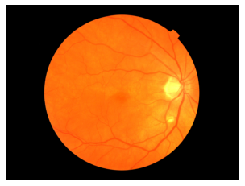

```python
import matplotlib.pyplot as plt
from PIL import Image

sample_folder = '/blue/ruogu.fang/charlietran/PD_Reproduction/data/Raw_Data/PD/'
# we want to choose the a random image from the folder so,
index = 0 # choose the 0th index from the folder
image = plt.imread(sample_folder + os.listdir(sample_folder)[index])
plt.imshow(image)
plt.axis('off')
```

# 3. Data resizing, splitting, and new-data folders.

(Estimated-Time) ~ 30 minutes to save all the folders

## Let's create new folders for the kfold data splitting, for

1. Overall
2. Prevalent
3. Incident

We will eventually use 5-repeated 5-fold fold validation. We will need 25 x 3 folders total.

R will stand for repetition - that is, a repetition of 5-fold validation

The data will be resized to 512 x 512 with cv2 during the process.

```python
os.makedirs('/blue/ruogu.fang/charlietran/PD_Reproduction/data/Overall_KFold_Data/', exist_ok = True)
os.makedirs('/blue/ruogu.fang/charlietran/PD_Reproduction/data/Overall_KFold_Data/R1/', exist_ok = True)
os.makedirs('/blue/ruogu.fang/charlietran/PD_Reproduction/data/Overall_KFold_Data/R2/', exist_ok = True)
os.makedirs('/blue/ruogu.fang/charlietran/PD_Reproduction/data/Overall_KFold_Data/R3/', exist_ok = True)
os.makedirs('/blue/ruogu.fang/charlietran/PD_Reproduction/data/Overall_KFold_Data/R4/', exist_ok = True)
os.makedirs('/blue/ruogu.fang/charlietran/PD_Reproduction/data/Overall_KFold_Data/R5/', exist_ok = True)

os.makedirs('/blue/ruogu.fang/charlietran/PD_Reproduction/data/Prevalent_KFold_Data/', exist_ok = True)
os.makedirs('/blue/ruogu.fang/charlietran/PD_Reproduction/data/Prevalent_KFold_Data/R1/', exist_ok = True)
os.makedirs('/blue/ruogu.fang/charlietran/PD_Reproduction/data/Prevalent_KFold_Data/R2/', exist_ok = True)
os.makedirs('/blue/ruogu.fang/charlietran/PD_Reproduction/data/Prevalent_KFold_Data/R3/', exist_ok = True)
os.makedirs('/blue/ruogu.fang/charlietran/PD_Reproduction/data/Prevalent_KFold_Data/R4/', exist_ok = True)
os.makedirs('/blue/ruogu.fang/charlietran/PD_Reproduction/data/Prevalent_KFold_Data/R5/', exist_ok = True)

os.makedirs('/blue/ruogu.fang/charlietran/PD_Reproduction/data/Incident_KFold_Data/', exist_ok = True)
os.makedirs('/blue/ruogu.fang/charlietran/PD_Reproduction/data/Incident_KFold_Data/R1/', exist_ok = True)
os.makedirs('/blue/ruogu.fang/charlietran/PD_Reproduction/data/Incident_KFold_Data/R2/', exist_ok = True)
os.makedirs('/blue/ruogu.fang/charlietran/PD_Reproduction/data/Incident_KFold_Data/R3/', exist_ok = True)
os.makedirs('/blue/ruogu.fang/charlietran/PD_Reproduction/data/Incident_KFold_Data/R4/', exist_ok = True)
os.makedirs('/blue/ruogu.fang/charlietran/PD_Reproduction/data/Incident_KFold_Data/R5/', exist_ok = True)
```

### This code will be repeated three times, depending on the PD / Prevalent / Incident.

The trick here about the data-splitting is that we will use five-fold cross validaion on the unique subject IDS themselves to organize the data.

We will be using the arguments PD_tag and HC_tag to be the name of the sub-folders from the base-folder (e.g.)

Overall:

- PD_tag = 'PD'
- HC_tag = 'HC'

Prevalent:

- PD_tag = 'PD_prevalent'
- HC_tag = 'PD_prevalent_hc'

Incident:

- PD_tag = 'PD_incident'
- HC_tag = 'PD_incident_hc'

```python
import os
from PIL import Image
import numpy as np
from sklearn.model_selection import StratifiedKFold
from scipy import stats
import matplotlib.pyplot as plt
import imageio
import cv2
import warnings
warnings.filterwarnings("ignore")


def data_splitter(input_path,
                  PD_tag,
                  HC_tag,
                  output_folder,
                  seed_number):
    path = input_path
    files = os.listdir(path)
    hc_path = os.path.join(path, PD_tag)
    pd_path = os.path.join(path, HC_tag)

    N = 5
    ids = []
    for img in os.listdir(pd_path):
        ids.append(img[0:7] + '_PD')
    for img in os.listdir(hc_path):
        ids.append(img[0:7] + '_CN')
    unique_ids = np.unique(ids) #

    labels = []

    for id in unique_ids:
        if id[-2:] == 'CN':
            labels.append(0)
        elif id[-2:] == 'PD':
            labels.append(1)

    labels = np.array(labels)
    count = 0
    dim = (512,512)
    kf_outer = StratifiedKFold(n_splits= 5, random_state = seed_number, shuffle = True)
    for train_index, test_index in kf_outer.split(unique_ids, labels):
        train_ids, test_ids = unique_ids[train_index], unique_ids[test_index]
        train_lbls, test_lbls = labels[train_index], labels[test_index]

        cn_train_list = []
        ad_train_list = []

        count += 1
        #print(pd_path)
        save_path = os.path.join(output_folder, str(count))
        #save_path = os.path.join(path, str(count))


        os.makedirs(os.path.join(save_path, 'train'), exist_ok = True) # create train file

        os.makedirs(os.path.join(save_path, 'test'), exist_ok = True) # create test file
        save_pd_train_path = os.path.join(save_path, 'train','PD')
        os.makedirs(save_pd_train_path, exist_ok = True)    # create tran/PD/
        save_hc_train_path = os.path.join(save_path, 'train', 'HC')
        os.makedirs(save_hc_train_path, exist_ok = True) # create /train/HC/

        for eid in train_ids:

            #split images to /train/PD/
            if eid[-2:] == 'PD':
                for img in os.listdir(pd_path):
                    if str(eid[0:7]) in img:
                        image =  plt.imread(os.path.join(pd_path,img))
                        image =cv2.resize(image, dim)
                        #print(os.path.join(save_pd_train_path,img))
                        imageio.imwrite(os.path.join(save_pd_train_path,img), image)

            # split images to /train/HC/
            if eid[-2:] == 'CN':
                for img in os.listdir(hc_path):
                    if str(eid[0:7]) in img:
                        image =  plt.imread(os.path.join(hc_path,img))
                        image =cv2.resize(image, dim)
                        imageio.imwrite(os.path.join(save_hc_train_path,img), image)

        save_pd_test_path = os.path.join(save_path, 'test','PD')
        os.makedirs(save_pd_test_path, exist_ok = True) # create /test/PD/
        save_hc_test_path = os.path.join(save_path, 'test', 'HC')
        os.makedirs(save_hc_test_path, exist_ok = True) # create /test/HC/

        for eid in test_ids:
            #split images to /test/PD/
            if eid[-2:] == 'PD':
                for img in os.listdir(pd_path):
                    if str(eid[0:7]) in img:
                        image =  plt.imread(os.path.join(pd_path,img))
                        image =cv2.resize(image, dim)
                        #print(os.path.join(save_pd_test_path,img))
                        imageio.imwrite(os.path.join(save_pd_test_path,img), image)
            #split images to /test/PD/
            if eid[-2:] == 'CN':
                for img in os.listdir(hc_path):
                    if str(eid[0:7]) in img:
                        image =  plt.imread(os.path.join(hc_path,img))
                        image = cv2.resize(image, dim)
                        imageio.imwrite(os.path.join(save_hc_test_path,img), image)

        #shutil.copy(input_path
```

# Overall Data Split

```python
import warnings
warnings.filterwarnings("ignore")
import logging
logging.getLogger().setLevel(logging.ERROR)

#self reminder I used this link: https://stackoverflow.com/questions/52165705/how-to-ignore-root-warnings
# to figure out how to remove the warnings

# Change paths 5 times and the seed numbers in [5, 25, 50, 75, 100]
# Remember that we are using the convention R1 R2 R3 R4 R5 for each repeated kfold
# Or make a better way by for looping or some other smart way.

data_splitter(input_path = '/blue/ruogu.fang/charlietran/PD_Reproduction/data/Raw_Data/',
              PD_tag = 'PD',
              HC_tag = 'HC',
              output_folder = '/blue/ruogu.fang/charlietran/PD_Reproduction/data/Overall_KFold_Data/R1/',
              seed_number = 5)

data_splitter(input_path = '/blue/ruogu.fang/charlietran/PD_Reproduction/data/Raw_Data/',
              PD_tag = 'PD',
              HC_tag = 'HC',
              output_folder = '/blue/ruogu.fang/charlietran/PD_Reproduction/data/Overall_KFold_Data/R2/',
              seed_number = 25)

data_splitter(input_path = '/blue/ruogu.fang/charlietran/PD_Reproduction/data/Raw_Data/',
              PD_tag = 'PD',
              HC_tag = 'HC',
              output_folder = '/blue/ruogu.fang/charlietran/PD_Reproduction/data/Overall_KFold_Data/R3/',
              seed_number = 50)

data_splitter(input_path = '/blue/ruogu.fang/charlietran/PD_Reproduction/data/Raw_Data/',
              PD_tag = 'PD',
              HC_tag = 'HC',
              output_folder = '/blue/ruogu.fang/charlietran/PD_Reproduction/data/Overall_KFold_Data/R4/',
              seed_number = 75)

data_splitter(input_path = '/blue/ruogu.fang/charlietran/PD_Reproduction/data/Raw_Data/',
              PD_tag = 'PD',
              HC_tag = 'HC',
              output_folder = '/blue/ruogu.fang/charlietran/PD_Reproduction/data/Overall_KFold_Data/R5/',
              seed_number = 100)
```

## Prevalent Data Split

We will be changing the tags to be PD_prevalent and PD_prevalent_hc along with the output prevalent folder.

```python
import warnings
warnings.filterwarnings("ignore")
import logging
logging.getLogger().setLevel(logging.ERROR)

#self reminder I used this link: https://stackoverflow.com/questions/52165705/how-to-ignore-root-warnings
# to figure out how to remove the warnings

# Change paths 5 times and the seed numbers in [5, 25, 50, 75, 100]
# Remember that we are using the convention R1 R2 R3 R4 R5 for each repeated kfold
# Or make a better way by for looping or some other smart way.





data_splitter(input_path = '/blue/ruogu.fang/charlietran/PD_Reproduction/data/Raw_Data/',
              PD_tag = 'PD_prevalent',
              HC_tag = 'PD_prevalent_hc',
              output_folder = '/blue/ruogu.fang/charlietran/PD_Reproduction/data/Prevalent_KFold_Data/R1/',
              seed_number = 5)

data_splitter(input_path = '/blue/ruogu.fang/charlietran/PD_Reproduction/data/Raw_Data/',
              PD_tag = 'PD_prevalent',
              HC_tag = 'PD_prevalent_hc',
              output_folder = '/blue/ruogu.fang/charlietran/PD_Reproduction/data/Prevalent_KFold_Data/R2/',
              seed_number = 25)

data_splitter(input_path = '/blue/ruogu.fang/charlietran/PD_Reproduction/data/Raw_Data/',
              PD_tag = 'PD_prevalent',
              HC_tag = 'PD_prevalent_hc',
              output_folder = '/blue/ruogu.fang/charlietran/PD_Reproduction/data/Prevalent_KFold_Data/R3/',
              seed_number = 50)

data_splitter(input_path = '/blue/ruogu.fang/charlietran/PD_Reproduction/data/Raw_Data/',
              PD_tag = 'PD_prevalent',
              HC_tag = 'PD_prevalent_hc',
              output_folder = '/blue/ruogu.fang/charlietran/PD_Reproduction/data/Prevalent_KFold_Data/R4/',
              seed_number = 75)

data_splitter(input_path = '/blue/ruogu.fang/charlietran/PD_Reproduction/data/Raw_Data/',
              PD_tag = 'PD_prevalent',
              HC_tag = 'PD_prevalent_hc',
              output_folder = '/blue/ruogu.fang/charlietran/PD_Reproduction/data/Prevalent_KFold_Data/R5/',
              seed_number = 100)
```

## Incident Data Split

We will be changing the tags to be PD_incident and PD_incident_hc along with the output incident folder.

```python
import warnings
warnings.filterwarnings("ignore")
import logging
logging.getLogger().setLevel(logging.ERROR)

#self reminder I used this link: https://stackoverflow.com/questions/52165705/how-to-ignore-root-warnings
# to figure out how to remove the warnings

# Change paths 5 times and the seed numbers in [5, 25, 50, 75, 100]
# Remember that we are using the convention R1 R2 R3 R4 R5 for each repeated kfold
# Or make a better way by for looping or some other smart way.

data_splitter(input_path = '/blue/ruogu.fang/charlietran/PD_Reproduction/data/Raw_Data/',
              PD_tag = 'PD_incident',
              HC_tag = 'PD_incident_hc',
              output_folder = '/blue/ruogu.fang/charlietran/PD_Reproduction/data/Incident_KFold_Data/R1/',
              seed_number = 5)

data_splitter(input_path = '/blue/ruogu.fang/charlietran/PD_Reproduction/data/Raw_Data/',
              PD_tag = 'PD_incident',
              HC_tag = 'PD_incident_hc',
              output_folder = '/blue/ruogu.fang/charlietran/PD_Reproduction/data/Incident_KFold_Data/R2/',
              seed_number = 25)

data_splitter(input_path = '/blue/ruogu.fang/charlietran/PD_Reproduction/data/Raw_Data/',
              PD_tag = 'PD_incident',
              HC_tag = 'PD_incident_hc',
              output_folder = '/blue/ruogu.fang/charlietran/PD_Reproduction/data/Incident_KFold_Data/R3/',
              seed_number = 50)

data_splitter(input_path = '/blue/ruogu.fang/charlietran/PD_Reproduction/data/Raw_Data/',
              PD_tag = 'PD_incident',
              HC_tag = 'PD_incident_hc',
              output_folder = '/blue/ruogu.fang/charlietran/PD_Reproduction/data/Incident_KFold_Data/R4/',
              seed_number = 75)

data_splitter(input_path = '/blue/ruogu.fang/charlietran/PD_Reproduction/data/Raw_Data/',
              PD_tag = 'PD_incident',
              HC_tag = 'PD_incident_hc',
              output_folder = '/blue/ruogu.fang/charlietran/PD_Reproduction/data/Incident_KFold_Data/R5/',
              seed_number = 100)
```

# 4. K-Fold Validation. Model training and Evaluation

### If you did not already know, use the command !nvidia-smi to check the gpu usage on hipergator in the case that someone else is using it. We will only be needing one gpu (A100)

Look at os.environ["CUDA_VISIBLE_DEVICES"] = "0" if you want to change gpu index

```python
!nvidia-smi
```

```python
import os
```

## **As you continue onward, you should create new cells for each model**

Your choices are alexnet, vgg, resnet, googlenet, inceptionv3. Go down to the bottom of the main section of each code and change

1. the DL model name [alexnet, vgg, resnet, googlenet, inceptionv3] or the ML model name [svm_linear, svm_rbf, logistic_regression, elastic_net]
2. the base directory of the project
3. the experiment tag: [overall, prevalent, incident]

## 4.1.1 Deep Learning Training (Overall, AlexNet)

```python
import warnings
warnings.filterwarnings("ignore")
import logging
logging.getLogger().setLevel(logging.ERROR)
```

```python
import torchvision.models as models
import torch
from torch.utils.data import DataLoader, random_split, ConcatDataset
import torchvision.datasets as datasets
import torch.nn as nn
import torch.optim as optim
import os
import torchvision.models as models
import numpy as np
from torchvision import transforms
#import tensorboard_logger as tb_logger
#from torchsampler import ImbalancedDatasetSampler
os.environ["CUDA_DEVICE_ORDER"] = "PCI_BUS_ID"
os.environ["CUDA_VISIBLE_DEVICES"] = "0"


def main():
    normalize = transforms.Normalize(mean=[0.485, 0.456, 0.406],
                                     std=[0.229, 0.224, 0.225])
    train_transform = transforms.Compose([
        transforms.RandomHorizontalFlip(p =0.4),
        transforms.RandomVerticalFlip(p = 0.4),
        transforms.RandomRotation(50),
        transforms.ToTensor(),
        transforms.Resize(256),
        normalize,
    ])
    val_transform = transforms.Compose([
        transforms.ToTensor(),
        transforms.Resize(256),
        normalize,
    ])

    train = datasets.ImageFolder(train_path, transform= train_transform)
    val  = datasets.ImageFolder(test_path, transform= train_transform)

    train_dataloader = DataLoader(train, batch_size=train_bsz, shuffle = True)
    val_dataloader = DataLoader(val, batch_size = val_bsz, shuffle = True)


    if model_name == 'alexnet':
        model = models.alexnet(pretrained = True)
        model.classifier[6] = nn.Linear(in_features = 4096, out_features = 2, bias = True)
    if model_name == 'vgg':
        model = models.vgg16(pretrained=True)
        model.classifier[6] = nn.Linear(in_features=4096, out_features=2, bias=True)
    if model_name == 'resnet':
        model = models.resnet50(pretrained = True) # Pre-train on imagenet
        model.fc = nn.Linear(in_features = 2048, out_features = 2) # Convert to binary classification
    if model_name == 'googlenet':
        model = models.googlenet(pretrained = True)
        model.fc = nn.Linear(in_features = 1024, out_features = 2)
    if model_name == 'inceptionv3':
        model = models.inception_v3(pretrained = True)
        model.fc = nn.Linear(in_features = 2048, out_features = 2)
        model.aux_logits = False



    model = model.cuda()
    criterion = nn.CrossEntropyLoss()
    optimizer = optim.Adam(model.parameters(), lr = learning_rate)

    def model_train(model, dataloader):
        model.train()
        tr_loss = []
        for i, data in enumerate(dataloader, 0):
            optimizer.zero_grad()
            image, labels = data
            image = image.float().cuda()
            labels = labels.long().cuda()
            output = model(image)

            #class_pred = torch.argmax(output, dim = 1)
            loss = criterion(output, labels)
            loss.backward()
            optimizer.step()
            tr_loss.append(loss.item())


       # print('Training Loss:', np.average(tr_loss, axis=0))
        avg_tr_loss = np.average(tr_loss, axis=0)
        return avg_tr_loss

    def model_eval(model, dataloader):
        model.eval()
        val_loss = []
        with torch.no_grad():
            for i, data in enumerate(dataloader, 0):
                optimizer.zero_grad()
                image, labels = data
                image = image.float().cuda()
                labels = labels.long().cuda()
                output = model(image)
                loss = criterion(output, labels)
                val_loss.append(loss.item())
      #  print('Validation Loss:', np.average(val_loss, axis=0))
        avg_val_loss = np.average(val_loss, axis=0)
        return avg_val_loss

    # initialize val loss counter to be high for early stopping method
    val_loss_counter = [100000000] # Initialize to a very large number

    for epoch in range(max_num_epochs):
        training_loss = model_train(model, train_dataloader)
        validation_loss = model_eval(model, val_dataloader)
       # print(epoch,'Training Loss:', training_loss, 'Validation Loss', validation_loss)
        if validation_loss <= np.amin(val_loss_counter):
            torch.save({'model_state_dict': model.state_dict(),
            }, output_model_dir )
            #torch.save({'model_state_dict': model.state_dict(), output_model_dir})
            print('Model has been saved to', output_model_dir)

        val_loss_counter.append(validation_loss)

if __name__ == '__main__':

    ### You need to change the base data_folder based on the eperiment (Overall, Prevalent, Incident)
    # Your options are [alexnet, vgg, resnet, googlenet, inceptionv3]
    model_name = 'alexnet'
    base_folder = '/blue/ruogu.fang/charlietran/PD_Reproduction/'
    experiment_tag = 'overall'


    if experiment_tag == 'overall':
        data_extension = 'Overall_KFold_Data'
    if experiment_tag == 'prevalent':
        data_extension == 'Prevalent_KFold_Data'
    if experiment_tag == 'incident':
        data_extension = 'Incident_KFold_Data'

    for j in range(1,6):
        for k in range(1,6):
            train_path = os.path.join(base_folder, 'data',  data_extension, 'R' + str(j),  str(k) , 'train')
            test_path =  os.path.join(base_folder, 'data', data_extension, 'R' + str(j), str(k) , 'test')
            output_model_dir = os.path.join(base_folder, 'models', experiment_tag, model_name,  model_name + 'weights' + '_' + str(j) + '_' + str(k) + '.pth')
            os.makedirs(os.path.join(base_folder, 'models', experiment_tag, model_name), exist_ok = True)
            learning_rate = 1e-4
            train_bsz = 64
            val_bsz = 64
            max_num_epochs = 2
            main()
    print('Confirm Model Output Name:', model_name)
```

```
Model has been saved to /blue/ruogu.fang/charlietran/PD_Reproduction/models/overall/alexnet/alexnetweights_1_1.pth
Model has been saved to /blue/ruogu.fang/charlietran/PD_Reproduction/models/overall/alexnet/alexnetweights_1_1.pth
Model has been saved to /blue/ruogu.fang/charlietran/PD_Reproduction/models/overall/alexnet/alexnetweights_1_2.pth
Model has been saved to /blue/ruogu.fang/charlietran/PD_Reproduction/models/overall/alexnet/alexnetweights_1_2.pth
Model has been saved to /blue/ruogu.fang/charlietran/PD_Reproduction/models/overall/alexnet/alexnetweights_1_3.pth
Model has been saved to /blue/ruogu.fang/charlietran/PD_Reproduction/models/overall/alexnet/alexnetweights_1_3.pth
Model has been saved to /blue/ruogu.fang/charlietran/PD_Reproduction/models/overall/alexnet/alexnetweights_1_4.pth
Model has been saved to /blue/ruogu.fang/charlietran/PD_Reproduction/models/overall/alexnet/alexnetweights_1_4.pth
Model has been saved to /blue/ruogu.fang/charlietran/PD_Reproduction/models/overall/alexnet/alexnetweights_1_5.pth
Model has been saved to /blue/ruogu.fang/charlietran/PD_Reproduction/models/overall/alexnet/alexnetweights_1_5.pth
Model has been saved to /blue/ruogu.fang/charlietran/PD_Reproduction/models/overall/alexnet/alexnetweights_2_1.pth
Model has been saved to /blue/ruogu.fang/charlietran/PD_Reproduction/models/overall/alexnet/alexnetweights_2_1.pth
Model has been saved to /blue/ruogu.fang/charlietran/PD_Reproduction/models/overall/alexnet/alexnetweights_2_2.pth
Model has been saved to /blue/ruogu.fang/charlietran/PD_Reproduction/models/overall/alexnet/alexnetweights_2_2.pth
Model has been saved to /blue/ruogu.fang/charlietran/PD_Reproduction/models/overall/alexnet/alexnetweights_2_3.pth
Model has been saved to /blue/ruogu.fang/charlietran/PD_Reproduction/models/overall/alexnet/alexnetweights_2_3.pth
Model has been saved to /blue/ruogu.fang/charlietran/PD_Reproduction/models/overall/alexnet/alexnetweights_2_4.pth
Model has been saved to /blue/ruogu.fang/charlietran/PD_Reproduction/models/overall/alexnet/alexnetweights_2_4.pth
Model has been saved to /blue/ruogu.fang/charlietran/PD_Reproduction/models/overall/alexnet/alexnetweights_2_5.pth
Model has been saved to /blue/ruogu.fang/charlietran/PD_Reproduction/models/overall/alexnet/alexnetweights_3_1.pth
Model has been saved to /blue/ruogu.fang/charlietran/PD_Reproduction/models/overall/alexnet/alexnetweights_3_1.pth
Model has been saved to /blue/ruogu.fang/charlietran/PD_Reproduction/models/overall/alexnet/alexnetweights_3_2.pth
Model has been saved to /blue/ruogu.fang/charlietran/PD_Reproduction/models/overall/alexnet/alexnetweights_3_2.pth
Model has been saved to /blue/ruogu.fang/charlietran/PD_Reproduction/models/overall/alexnet/alexnetweights_3_3.pth
Model has been saved to /blue/ruogu.fang/charlietran/PD_Reproduction/models/overall/alexnet/alexnetweights_3_4.pth
Model has been saved to /blue/ruogu.fang/charlietran/PD_Reproduction/models/overall/alexnet/alexnetweights_3_5.pth
Model has been saved to /blue/ruogu.fang/charlietran/PD_Reproduction/models/overall/alexnet/alexnetweights_3_5.pth
Model has been saved to /blue/ruogu.fang/charlietran/PD_Reproduction/models/overall/alexnet/alexnetweights_4_1.pth
Model has been saved to /blue/ruogu.fang/charlietran/PD_Reproduction/models/overall/alexnet/alexnetweights_4_1.pth
Model has been saved to /blue/ruogu.fang/charlietran/PD_Reproduction/models/overall/alexnet/alexnetweights_4_2.pth
Model has been saved to /blue/ruogu.fang/charlietran/PD_Reproduction/models/overall/alexnet/alexnetweights_4_2.pth
Model has been saved to /blue/ruogu.fang/charlietran/PD_Reproduction/models/overall/alexnet/alexnetweights_4_3.pth
Model has been saved to /blue/ruogu.fang/charlietran/PD_Reproduction/models/overall/alexnet/alexnetweights_4_4.pth
Model has been saved to /blue/ruogu.fang/charlietran/PD_Reproduction/models/overall/alexnet/alexnetweights_4_4.pth
Model has been saved to /blue/ruogu.fang/charlietran/PD_Reproduction/models/overall/alexnet/alexnetweights_4_5.pth
Model has been saved to /blue/ruogu.fang/charlietran/PD_Reproduction/models/overall/alexnet/alexnetweights_4_5.pth
Model has been saved to /blue/ruogu.fang/charlietran/PD_Reproduction/models/overall/alexnet/alexnetweights_5_1.pth
Model has been saved to /blue/ruogu.fang/charlietran/PD_Reproduction/models/overall/alexnet/alexnetweights_5_1.pth
Model has been saved to /blue/ruogu.fang/charlietran/PD_Reproduction/models/overall/alexnet/alexnetweights_5_2.pth
Model has been saved to /blue/ruogu.fang/charlietran/PD_Reproduction/models/overall/alexnet/alexnetweights_5_3.pth
Model has been saved to /blue/ruogu.fang/charlietran/PD_Reproduction/models/overall/alexnet/alexnetweights_5_3.pth
Model has been saved to /blue/ruogu.fang/charlietran/PD_Reproduction/models/overall/alexnet/alexnetweights_5_4.pth
Model has been saved to /blue/ruogu.fang/charlietran/PD_Reproduction/models/overall/alexnet/alexnetweights_5_4.pth
Model has been saved to /blue/ruogu.fang/charlietran/PD_Reproduction/models/overall/alexnet/alexnetweights_5_5.pth
Model has been saved to /blue/ruogu.fang/charlietran/PD_Reproduction/models/overall/alexnet/alexnetweights_5_5.pth
Confirm Model Output Name: alexnet
```

# 4.1.1 Testing (Overall, AlexNet)

```python
import torch
from torch.utils.data import DataLoader, ConcatDataset, random_split
import torchvision.datasets as datasets
from torchvision import transforms
import torch.nn as nn
import torch.optim as optim
import os
import torch.backends.cudnn as cudnn
import torchvision.models as models
import numpy as np
os.environ["CUDA_DEVICE_ORDER"] = "PCI_BUS_ID"
os.environ["CUDA_VISIBLE_DEVICES"] = "0"
from sklearn.metrics import classification_report
from torchvision import transforms
from sklearn.metrics import roc_auc_score

def main():
    normalize = transforms.Normalize(mean=[0.485, 0.456, 0.406],
                                     std=[0.229, 0.224, 0.225])
    test_transform = transforms.Compose([
        transforms.ToTensor(),
        transforms.Resize(256),
        normalize,
    ])

    test  = datasets.ImageFolder(test_path, transform= test_transform)
    test_dataloader = DataLoader(test, batch_size=bsz, shuffle = False)
    if model_name == 'alexnet':
        model = models.alexnet(pretrained = True)
        model.classifier[6] = nn.Linear(in_features = 4096, out_features = 2, bias = True)
    if model_name == 'vgg':
        model = models.vgg16(pretrained=True)
        model.classifier[6] = nn.Linear(in_features=4096, out_features=2, bias=True)
    if model_name == 'resnet':
        model = models.resnet50(pretrained = True) # Pre-train on imagenet
        model.fc = nn.Linear(in_features = 2048, out_features = 2) # Convert to binary classification
    if model_name == 'googlenet':
        model = models.googlenet(pretrained = True)
        model.fc = nn.Linear(in_features = 1024, out_features = 2)
    if model_name == 'inceptionv3':
        model = models.inception_v3(pretrained = True)
        model.fc = nn.Linear(in_features = 2048, out_features = 2)
        model.aux_logits = False

    checkpoint = torch.load(output_model_dir)
    model.load_state_dict(checkpoint['model_state_dict'])
    model.eval()
    model = model.cuda()

    def computeAUC(dataGT, dataPRED):
        datanpGT = dataGT.cpu().numpy()
        datanpPRED = dataPRED.cpu().numpy()
        return roc_auc_score(datanpGT, datanpPRED)

    def class_report(dataGT, predCLASS):
        datanpGT = dataGT.cpu().numpy()
        datanppredCLASS = predCLASS.cpu().numpy()

        return classification_report(datanpGT, datanppredCLASS, digits = 3, output_dict = True)

    def model_test(model, dataloader):
        model.eval()
        outGT = torch.FloatTensor().cuda()
        outPRED = torch.FloatTensor().cuda()
        outCLASS = torch.FloatTensor().cuda()
        with torch.no_grad():
            for i, data in enumerate(dataloader, 0):
                image, labels = data
                image = image.float().cuda()
                labels = labels.float().cuda()
                output = model(image) # The output current is (N, C) where it is actually (N, 2)
                m = nn.Softmax(dim = 1)
                output_probabilities = m(output)
                class_pred = torch.argmax(output_probabilities, dim = 1)
                outPRED = torch.cat((outPRED, output_probabilities[:, -1]), 0)
                outGT = torch.cat((outGT, labels), 0)
                outCLASS = torch.cat((outCLASS, class_pred), 0)
        auc_test = computeAUC(outGT, outPRED)
        report = class_report(outGT, outCLASS)
       # print(report)
        return auc_test, report, outPRED, outCLASS, outGT
    auc_test,report, outPRED, outCLASS, outGT = model_test(model, test_dataloader)
   # print('TEST AUC:', auc_test)
    auc_scores.append(auc_test)
    accuracy_scores.append(report['accuracy'])
    ppv_scores.append(report['1.0']['precision'])
    npv_scores.append(report['0.0']['precision'])
    sensitivity_scores.append(report['1.0']['recall'])
    specificity_scores.append(report['0.0']['recall'])
    f1_scores.append(report['1.0']['f1-score'])

    parkinson_probability.append(outPRED.cpu().detach().numpy())
    class_predictions.append(outCLASS.cpu().detach().numpy())
    ground_truth.append(outGT.cpu().detach().numpy())
   # print(report['accuracy'], ',')



if __name__ == '__main__':
    auc_scores = []
    accuracy_scores = []
    ppv_scores = []
    npv_scores = []
    sensitivity_scores = []
    specificity_scores = []
    f1_scores = []
    parkinson_probability = []
    class_predictions = []
    ground_truth = []

    model_name = 'alexnet'
    base_folder = '/blue/ruogu.fang/charlietran/PD_Reproduction/'
    experiment_tag = 'overall'


    if experiment_tag == 'overall':
        data_extension = 'Overall_KFold_Data'
    if experiment_tag == 'prevalent':
        data_extension == 'Prevalent_KFold_Data'
    if experiment_tag == 'incident':
        data_extension = 'Incident_KFold_Data'


    for j in range(1,6):
        for k in range(1,6):
            train_path = os.path.join(base_folder, 'data',  data_extension, 'R' + str(j),  str(k) , 'train')
            test_path =  os.path.join(base_folder, 'data', data_extension, 'R' + str(j), str(k) , 'test')
            output_model_dir = os.path.join(base_folder, 'models', experiment_tag, model_name,  model_name + 'weights' + '_' + str(j) + '_' + str(k) + '.pth')
            bsz = 64
            max_num_epochs = 100
            main()

    print('---------------------------------------------------------------')
    print('AVERAGE SCORE REPORT')
    print('---------------------------------------------------------------')
    print('AVERAGE AUC', '{:.2f}'.format(np.average(auc_scores)),'({:.2f})'.format(np.std(auc_scores)))
    print('AVERAGE Accuracy', '{:.2f}'.format(np.average(accuracy_scores)),'({:.2f})'.format(np.std(accuracy_scores)))
    print('AVERAGE PPV', '{:.2f}'.format(np.average(ppv_scores)),'({:.2f})'.format(np.std(ppv_scores)))
    print('AVERAGE NPV', '{:.2f}'.format(np.average(npv_scores)), '({:.2f})'.format(np.std(npv_scores)))
    print('AVERAGE Sensitivity', '{:.2f}'.format(np.average(sensitivity_scores)), '({:.2f})'.format(np.std(sensitivity_scores)))
    print('AVERAGE Specificity', '{:.2f}'.format(np.average(specificity_scores)), '({:.2f})'.format(np.std(specificity_scores)))
    print('AVERAGE F1 scores', '{:.2f}'.format(np.average(f1_scores)),'({:.2f})'.format(np.std(f1_scores)))
    print('---------------------------------------------------------------')



    output_base_dir_name = os.path.join(base_folder, 'results', experiment_tag, model_name)
    os.makedirs(output_base_dir_name, exist_ok = True)

    np.save(os.path.join(output_base_dir_name, model_name + '_' + 'auc_scores.npy'), auc_scores)
    np.save(os.path.join(output_base_dir_name, model_name + '_' + 'accuracy_scores.npy'), accuracy_scores)
    np.save(os.path.join(output_base_dir_name, model_name + '_' + 'ppv_scores.npy'), ppv_scores)
    np.save(os.path.join(output_base_dir_name, model_name + '_' + 'npv_score.npy'), npv_scores)
    np.save(os.path.join(output_base_dir_name, model_name + '_' + 'sensitivity_scores.npy'), sensitivity_scores)
    np.save(os.path.join(output_base_dir_name, model_name + '_' + 'specificity_scores.npy'), specificity_scores)
    np.save(os.path.join(output_base_dir_name, model_name + '_' + 'f1_scores.npy'), f1_scores)
    np.save(os.path.join(output_base_dir_name, model_name + '_' + 'pd_probability.npy'), parkinson_probability)
    np.save(os.path.join(output_base_dir_name, model_name + '_' + 'class_predictions.npy'), class_predictions)
    np.save(os.path.join(output_base_dir_name, model_name + '_' + 'ground_truth.npy'), ground_truth)


    # print statements
    print('SAVING:', os.path.join(output_base_dir_name, model_name + '_' + 'auc_scores.npy'))
    print('SAVING:', os.path.join(output_base_dir_name, model_name + '_' + 'accuracy_scores.npy'))
    print('SAVING:', os.path.join(output_base_dir_name, model_name +  '_' + 'ppv_scores.npy'))
    print('SAVING:', os.path.join(output_base_dir_name, model_name + '_' + 'npv_scores.npy'))
    print('SAVING:', os.path.join(output_base_dir_name, model_name + '_' + 'sensitivity_scores.npy'))
    print('SAVING:', os.path.join(output_base_dir_name, model_name + '_' + 'specificity_scores.npy'))
    print('SAVING:', os.path.join(output_base_dir_name, model_name + '_' + 'prob_outputs.npy'))
    print('SAVING:', os.path.join(output_base_dir_name, model_name + '_' + 'pd_probability.npy'))
    print('SAVING:', os.path.join(output_base_dir_name, model_name + '_' + 'class_predictions.npy'))
    print('SAVING:', os.path.join(output_base_dir_name, model_name + '_' + 'f1_scores.npy'))
```

[output not shown]

[output cut: 18 more lines]

```
---------------------------------------------------------------
AVERAGE SCORE REPORT
---------------------------------------------------------------
AVERAGE AUC 0.59 (0.09)
AVERAGE Accuracy 0.52 (0.05)
AVERAGE PPV 0.51 (0.28)
AVERAGE NPV 0.47 (0.33)
AVERAGE Sensitivity 0.59 (0.42)
AVERAGE Specificity 0.45 (0.43)
AVERAGE F1 scores 0.45 (0.27)
---------------------------------------------------------------
SAVING: /blue/ruogu.fang/charlietran/PD_Reproduction/results/overall/alexnet/alexnet_auc_scores.npy
SAVING: /blue/ruogu.fang/charlietran/PD_Reproduction/results/overall/alexnet/alexnet_accuracy_scores.npy
SAVING: /blue/ruogu.fang/charlietran/PD_Reproduction/results/overall/alexnet/alexnet_ppv_scores.npy
SAVING: /blue/ruogu.fang/charlietran/PD_Reproduction/results/overall/alexnet/alexnet_npv_scores.npy
SAVING: /blue/ruogu.fang/charlietran/PD_Reproduction/results/overall/alexnet/alexnet_sensitivity_scores.npy
SAVING: /blue/ruogu.fang/charlietran/PD_Reproduction/results/overall/alexnet/alexnet_specificity_scores.npy
SAVING: /blue/ruogu.fang/charlietran/PD_Reproduction/results/overall/alexnet/alexnet_prob_outputs.npy
SAVING: /blue/ruogu.fang/charlietran/PD_Reproduction/results/overall/alexnet/alexnet_pd_probability.npy
SAVING: /blue/ruogu.fang/charlietran/PD_Reproduction/results/overall/alexnet/alexnet_class_predictions.npy
SAVING: /blue/ruogu.fang/charlietran/PD_Reproduction/results/overall/alexnet/alexnet_f1_scores.npy
```

# 5. Machine Learning (SVM, Logistic Regression, ElasticNet)

```python
import os
import matplotlib as mpl
import matplotlib.pyplot as plt
from IPython.display import display


import pandas as pd
import numpy as np

from sklearn.discriminant_analysis import LinearDiscriminantAnalysis

from PIL import Image

from skimage.feature import hog
from skimage.color import rgb2gray

from sklearn.model_selection import train_test_split
from sklearn.metrics import accuracy_score,f1_score

from sklearn.preprocessing import StandardScaler
from sklearn.decomposition import PCA
from sklearn.svm import SVC

from sklearn.metrics import roc_curve, auc
from sklearn.metrics import confusion_matrix
from sklearn import random_projection

from sklearn.preprocessing import StandardScaler
from sklearn.ensemble import RandomForestClassifier
from sklearn.datasets import make_classification
from sklearn.linear_model import LogisticRegression


from sklearn.tree import DecisionTreeClassifier
from sklearn.metrics import roc_auc_score
from sklearn.metrics import classification_report

import cv2
import time


def load_images(fold_path):
    files = os.listdir(fold_path)

    cn_path = fold_path + '/HC/'
    pd_path = fold_path + '/PD/'
    cn_image_path = os.listdir(cn_path)
    pd_image_path = os.listdir(pd_path)
    cn_image = plt.imread(os.path.join(cn_path,cn_image_path[0]))
    cn_image = cv2.resize(cn_image, (256,256))
    m = len(cn_image)

    cn_image_resize = np.reshape(cn_image, (1,m*m*3))
    cn = cn_image_resize

    pd_image = plt.imread(os.path.join(pd_path,pd_image_path[0]))
    pd_image = cv2.resize(pd_image, (256,256))
    pd_image_resize = np.reshape(pd_image, (1,m*m*3))
    pd = pd_image_resize


    label = np.concatenate((np.zeros(len(cn_image_path)),np.ones(len(pd_image_path))))
    for i in range(1, len(cn_image_path)):
        #print(i)
        cn_image = plt.imread(os.path.join(cn_path,cn_image_path[i]))
        cn_image = cv2.resize(cn_image, (256,256))
        cn_image_resize = np.reshape(cn_image, (1,m*m*3))

        cn = np.concatenate((cn, cn_image_resize), axis = 0)

    for i in range(1, len(pd_image_path)):
         pd_image = plt.imread(os.path.join(pd_path,pd_image_path[i]))
         pd_image = cv2.resize(pd_image, (256,256))
         pd_image_resize = np.reshape(pd_image, (1,m*m*3))
         pd = np.concatenate((pd, pd_image_resize), axis = 0)

    dataset = np.concatenate((cn,pd),axis = 0)


    return dataset, label



def main():
   # files = os.listdir(path)
    #test_path = path + '/test/'
   # train_path = path + '/train/'


    X_train, y_train = load_images(train_path)
    X_test, y_test = load_images(test_path)
    #print('len of train set', X_train.shape, 'len of test set', X_test.shape)

    scaler = StandardScaler()
    scaler.fit(X_train)
    # I actually have no idea if you need to use X_train = , or just use scaler.fit(X_train).
    # just do this I guess

    X_train = scaler.transform(X_train)
    X_test = scaler.transform(X_test)
    #scaler.transform(X_train)

    dtc = SVC(kernel='linear', probability=True, random_state=42)
    dtc.fit(X_train, y_train)

    if model_name == 'svm_linear':
        model = SVC(kernel  = 'linear', probability = True, random_state = 42)
    if model_name == 'svm_rbf':
        model = SVC(kernel  = 'rbf', probability = True, random_state = 42)
    if model_name == 'logistic_regression':
        model = LogisticRegression()
    if model_name == 'elastic_net':
        model = LogisticRegression(penalty = 'elasticnet', solver = 'saga', l1_ratio = 0.5)
    model.fit(X_train, y_train)
    #dtc = LogisticRegression(penalty = 'elasticnet', solver = 'saga', l1_ratio = 0.5)
    #dtc.fit(X_train, y_train)

    y_pred = model.predict_proba(X_test)
    y_class = np.argmax(y_pred, axis = 1)
    # y_class = np.rint(y_pred)
    report = classification_report(y_test, y_class, digits = 3, output_dict = True)
    #calculate auc
    auc_test = roc_auc_score(y_test, y_pred[:, 1])
    auc_scores.append(auc_test)
    accuracy_scores.append(report['accuracy'])
    ppv_scores.append(report['1.0']['precision'])
    npv_scores.append(report['0.0']['precision'])
    sensitivity_scores.append(report['1.0']['recall'])
    specificity_scores.append(report['0.0']['recall'])
    f1_scores.append(report['1.0']['f1-score'])


    # append the class predictions
    prob_outputs.append(y_pred)
    parkinson_probability.append(y_pred[:, 1])
    class_predictions.append(y_class)
    ground_truth.append(y_test)
if __name__ == '__main__':

# Not sure if I actually need this but store it just incase


    prob_outputs = []
    parkinson_probability = []
    class_predictions = []
    ground_truth = []

    auc_scores = []
    accuracy_scores = []
    ppv_scores = []
    npv_scores = []
    sensitivity_scores = []
    specificity_scores = []
    f1_scores = []

    model_name = 'svm_rbf'
    base_folder = '/blue/ruogu.fang/charlietran/PD_Reproduction/'
    experiment_tag = 'overall'
    ########################

    if experiment_tag == 'overall':
        data_extension = 'Overall_KFold_Data'
    if experiment_tag == 'prevalent':
        data_extension = 'Prevalent_KFold_Data'
    if experiment_tag == 'incident':
        data_extension = 'Incident_KFold_Data'


    for j in range(1,6):
        for k in range(1,6):
            time1 = time.time()
            train_path = os.path.join(base_folder, 'data',  data_extension, 'R' + str(j),  str(k) , 'train')
            test_path =  os.path.join(base_folder, 'data', data_extension, 'R' + str(j), str(k) , 'test')
            main()
            time2 = time.time()
            print('Time (minutes) to Run CV:', (time2 - time1) / 60)
    print('---------------------------------------------------------------')
    print('AVERAGE SCORE REPORT')
    print('---------------------------------------------------------------')
    print('AVERAGE AUC', '{:.2f}'.format(np.average(auc_scores)),'({:.2f})'.format(np.std(auc_scores)))
    print('AVERAGE Accuracy', '{:.2f}'.format(np.average(accuracy_scores)),'({:.2f})'.format(np.std(accuracy_scores)))
    print('AVERAGE PPV', '{:.2f}'.format(np.average(ppv_scores)),'({:.2f})'.format(np.std(ppv_scores)))
    print('AVERAGE NPV', '{:.2f}'.format(np.average(npv_scores)), '({:.2f})'.format(np.std(npv_scores)))
    print('AVERAGE Sensitivity', '{:.2f}'.format(np.average(sensitivity_scores)), '({:.2f})'.format(np.std(sensitivity_scores)))
    print('AVERAGE Specificity', '{:.2f}'.format(np.average(specificity_scores)), '({:.2f})'.format(np.std(specificity_scores)))
    print('AVERAGE F1 scores', '{:.2f}'.format(np.average(f1_scores)),'({:.2f})'.format(np.std(f1_scores)))
    print('---------------------------------------------------------------')



    output_base_dir_name = os.path.join(base_folder, 'results', experiment_tag, model_name)
    os.makedirs(output_base_dir_name, exist_ok = True)

    np.save(os.path.join(output_base_dir_name, model_name + '_' + 'auc_scores.npy'), auc_scores)
    np.save(os.path.join(output_base_dir_name, model_name + '_' + 'accuracy_scores.npy'), accuracy_scores)
    np.save(os.path.join(output_base_dir_name, model_name + '_' + 'ppv_scores.npy'), ppv_scores)
    np.save(os.path.join(output_base_dir_name, model_name + '_' + 'npv_score.npy'), npv_scores)
    np.save(os.path.join(output_base_dir_name, model_name + '_' + 'sensitivity_scores.npy'), sensitivity_scores)
    np.save(os.path.join(output_base_dir_name, model_name + '_' + 'specificity_scores.npy'), specificity_scores)
    np.save(os.path.join(output_base_dir_name, model_name + '_' + 'f1_scores.npy'), f1_scores)
    np.save(os.path.join(output_base_dir_name, model_name + '_' + 'pd_probability.npy'), parkinson_probability)
    np.save(os.path.join(output_base_dir_name, model_name + '_' + 'class_predictions.npy'), class_predictions)
    np.save(os.path.join(output_base_dir_name, model_name + '_' + 'ground_truth.npy'), ground_truth)


    # print statements
    print('SAVING:', os.path.join(output_base_dir_name, model_name + '_' + 'auc_scores.npy'))
    print('SAVING:', os.path.join(output_base_dir_name, model_name + '_' + 'accuracy_scores.npy'))
    print('SAVING:', os.path.join(output_base_dir_name, model_name +  '_' + 'ppv_scores.npy'))
    print('SAVING:', os.path.join(output_base_dir_name, model_name + '_' + 'npv_scores.npy'))
    print('SAVING:', os.path.join(output_base_dir_name, model_name + '_' + 'sensitivity_scores.npy'))
    print('SAVING:', os.path.join(output_base_dir_name, model_name + '_' + 'specificity_scores.npy'))
    print('SAVING:', os.path.join(output_base_dir_name, model_name + '_' + 'prob_outputs.npy'))
    print('SAVING:', os.path.join(output_base_dir_name, model_name + '_' + 'pd_probability.npy'))
    print('SAVING:', os.path.join(output_base_dir_name, model_name + '_' + 'class_predictions.npy'))
    print('SAVING:', os.path.join(output_base_dir_name, model_name + '_' + 'f1_scores.npy'))
```

```
Time (minutes) to Run CV: 0.45124448935190836
Time (minutes) to Run CV: 0.43802420298258465
Time (minutes) to Run CV: 0.453930938243866
Time (minutes) to Run CV: 0.426593021551768
Time (minutes) to Run CV: 0.4633716861406962
Time (minutes) to Run CV: 0.44585131804148354
Time (minutes) to Run CV: 0.46480891307195027
Time (minutes) to Run CV: 0.452748437722524
Time (minutes) to Run CV: 0.44104435841242473
Time (minutes) to Run CV: 0.4495703379313151
Time (minutes) to Run CV: 0.4670507033665975
Time (minutes) to Run CV: 0.4244913140932719
Time (minutes) to Run CV: 0.44767245451609294
Time (minutes) to Run CV: 0.4858778198560079
Time (minutes) to Run CV: 0.4584403157234192
Time (minutes) to Run CV: 0.4654181480407715
Time (minutes) to Run CV: 0.45266817808151244
Time (minutes) to Run CV: 0.4363352576891581
Time (minutes) to Run CV: 0.46234946648279823
Time (minutes) to Run CV: 0.4494645516077677
Time (minutes) to Run CV: 0.456579069296519
Time (minutes) to Run CV: 0.44996878306070964
Time (minutes) to Run CV: 0.46237297455469767
Time (minutes) to Run CV: 0.45389729340871177
Time (minutes) to Run CV: 0.44964824120203656
---------------------------------------------------------------
AVERAGE SCORE REPORT
---------------------------------------------------------------
AVERAGE AUC 0.76 (0.08)
AVERAGE Accuracy 0.69 (0.07)
AVERAGE PPV 0.72 (0.10)
AVERAGE NPV 0.68 (0.07)
AVERAGE Sensitivity 0.65 (0.10)
AVERAGE Specificity 0.73 (0.12)
AVERAGE F1 scores 0.67 (0.07)
---------------------------------------------------------------
SAVING: /blue/ruogu.fang/charlietran/PD_Reproduction/results/overall/svm_rbf/svm_rbf_auc_scores.npy
SAVING: /blue/ruogu.fang/charlietran/PD_Reproduction/results/overall/svm_rbf/svm_rbf_accuracy_scores.npy
SAVING: /blue/ruogu.fang/charlietran/PD_Reproduction/results/overall/svm_rbf/svm_rbf_ppv_scores.npy
SAVING: /blue/ruogu.fang/charlietran/PD_Reproduction/results/overall/svm_rbf/svm_rbf_npv_scores.npy
SAVING: /blue/ruogu.fang/charlietran/PD_Reproduction/results/overall/svm_rbf/svm_rbf_sensitivity_scores.npy
SAVING: /blue/ruogu.fang/charlietran/PD_Reproduction/results/overall/svm_rbf/svm_rbf_specificity_scores.npy
SAVING: /blue/ruogu.fang/charlietran/PD_Reproduction/results/overall/svm_rbf/svm_rbf_prob_outputs.npy
SAVING: /blue/ruogu.fang/charlietran/PD_Reproduction/results/overall/svm_rbf/svm_rbf_pd_probability.npy
SAVING: /blue/ruogu.fang/charlietran/PD_Reproduction/results/overall/svm_rbf/svm_rbf_class_predictions.npy
SAVING: /blue/ruogu.fang/charlietran/PD_Reproduction/results/overall/svm_rbf/svm_rbf_f1_scores.npy
```

```python
np.load('/blue/ruogu.fang/charlietran/PD_Reproduction/results/overall/alexnet.npy')
```

```
array('alexnet_ground_truth.npy', dtype='<U24')
```

# 6. Test-Time Model XAI

## We will run this code in two parts

1. Quantiative (Explaination Infidelity and Insensitivity)
2. Qualitative - Visuals (Guided Backpropagation)

# 6.1 Quantiative (Explanation Infidelity and Sensitivity)

```python
import torch
from torch.utils.data import DataLoader, ConcatDataset, random_split
import torchvision.datasets as datasets
from torchvision import transforms
import torch.nn as nn
import torch.optim as optim
import os
import torch.backends.cudnn as cudnn
import torchvision.models as models
import numpy as np
os.environ["CUDA_DEVICE_ORDER"] = "PCI_BUS_ID"
os.environ["CUDA_VISIBLE_DEVICES"] = "2"
from sklearn.metrics import classification_report
from torchvision import transforms
from sklearn.metrics import roc_auc_score
from captum.attr import GuidedBackprop
from captum.attr import Saliency
from captum.metrics import sensitivity_max
from captum.metrics import infidelity
from captum.attr import GuidedGradCam
from captum.attr import visualization as viz
from captum.attr import LayerActivation
from captum.attr import NoiseTunnel
def main():
    normalize = transforms.Normalize(mean=[0.485, 0.456, 0.406],
                                     std=[0.229, 0.224, 0.225])
    test_transform = transforms.Compose([
        transforms.ToTensor(),
        transforms.Resize(256),
        normalize,
    ])

    class ImageFolderWithPaths(datasets.ImageFolder):
        """Custom dataset that includes image file paths. Extends
        torchvision.datasets.ImageFolder
        """

        # override the __getitem__ method. this is the method that dataloader calls
        def __getitem__(self, index):
            # this is what ImageFolder normally returns
            original_tuple = super(ImageFolderWithPaths, self).__getitem__(index)
            # the image file path
            path = self.imgs[index][0]
            # make a new tuple that includes original and the path
            tuple_with_path = (original_tuple + (path,))
            return tuple_with_path


   # dataset_paths_var = ImageFolderWithPaths(test_path) # our custom dataset
   # paths_dataloader = DataLoader(dataset_paths_var)

    test = ImageFolderWithPaths(test_path, transform = test_transform)

    #test  = datasets.ImageFolder(test_path, transform= test_transform)
    test_dataloader = DataLoader(test, batch_size=bsz, shuffle = False)
    model = models.alexnet(pretrained = True)
    model.classifier[6] = nn.Linear(in_features = 4096, out_features = 2)
    #model = models.googlenet(pretrained = True)
    #model.fc = nn.Linear(in_features = 1024, out_features = 2)
    checkpoint = torch.load(output_model_dir)
    model.load_state_dict(checkpoint['model_state_dict'])
    model.eval()
    model = model.cuda()



    def computeAUC(dataGT, dataPRED):
        datanpGT = dataGT.cpu().numpy()
        datanpPRED = dataPRED.cpu().numpy()
        return roc_auc_score(datanpGT, datanpPRED)

    def perturb_fn(inputs):
        noise = torch.tensor(np.random.normal(0, 0.01, inputs.shape)).float().cuda()
        return (noise).cuda(), (inputs - noise).cuda()

    def model_test(model, dataloader):
        model.eval()
        outGT = torch.FloatTensor().cuda()
        outPRED = torch.FloatTensor().cuda()
        outCLASS = torch.FloatTensor().cuda()
        outATTRIBUTION = torch.FloatTensor().cuda()
        outINFIDELITY = torch.FloatTensor().cuda()
        outSENSITIVITY = torch.FloatTensor().cuda()
        attribution_method = attribution_method = GuidedBackprop(model)
       # attribution_method = Saliency(model)
        image_volume = torch.FloatTensor().cuda()
        paths_array = []
        with torch.no_grad():
            for i, data in enumerate(dataloader, 0):
                image, labels, paths = data
                image = image.float().cuda()
                image_volume = torch.cat((image_volume, image))
                attribution = attribution_method.attribute(image, target = 1)
                labels = labels.float().cuda()
                output = model(image) # The output current is (N, C) where it is actually (N, 2)
                m = nn.Softmax(dim = 1)
                output_probabilities = m(output)
                class_pred = torch.argmax(output_probabilities, dim = 1)
                # I want to convert
                outPRED = torch.cat((outPRED, output_probabilities), 0)
                outGT = torch.cat((outGT, labels), 0)
                outCLASS = torch.cat((outCLASS, class_pred), 0)
                outATTRIBUTION = torch.cat((outATTRIBUTION, attribution))
                sens = sensitivity_max(attribution_method.attribute, image, target = 1, n_perturb_samples = 32)
                infid = infidelity(model, perturb_fn, image, attribution, max_examples_per_batch = image.shape[0], n_perturb_samples = 32)
                paths_array.append(paths)
                outSENSITIVITY = torch.cat((outSENSITIVITY, sens))
                outINFIDELITY = torch.cat((outINFIDELITY, infid))

        return outPRED, outCLASS, outGT, outATTRIBUTION, image_volume, paths_array[0], outINFIDELITY, outSENSITIVITY


    outPRED, outCLASS, outGT, outATTRIBUTION, image_volume, paths_array, outINFIDELITY, outSENSITIVITY = model_test(model, test_dataloader)
    outINFIDELITY_scores.append(np.average(outINFIDELITY.cpu().detach().numpy()))
    outSENSITIVITY_scores.append(np.average(outSENSITIVITY.cpu().detach().numpy()))

    print('ITERATION: ', counter + 1, 'AVERAGE INFIDELITY', '{:.6f}'.format(np.average(outINFIDELITY.cpu().detach().numpy())))
    print('ITERATION: ', counter + 1, 'AVERAGE SENSITIVITY', '{:.3f}'.format(np.average(outSENSITIVITY.cpu().detach().numpy())))



    #auc_test = computeAUC(outGT, outPRED[:, -1])
    #print('AVERAGE AUC', auc_test)
    #return outPRED, outCLASS, outGT, outATTRIBUTION, image_volume, paths_array, outINFIDELITY, outSENSITIVITY

if __name__ == '__main__':
    outINFIDELITY_scores = []
    outSENSITIVITY_scores = []
    counter = 0


    model_name = 'alexnet'
    base_folder = '/blue/ruogu.fang/charlietran/PD_Reproduction/'
    experiment_tag = 'overall'


    if experiment_tag == 'overall':
        data_extension = 'Overall_KFold_Data'
    if experiment_tag == 'prevalent':
        data_extension == 'Prevalent_KFold_Data'
    if experiment_tag == 'incident':
        data_extension = 'Incident_KFold_Data'

    for j in range(1,6):
        for k in range(1,6):
            train_path = os.path.join(base_folder, 'data',  data_extension, 'R' + str(j),  str(k) , 'train')
            test_path =  os.path.join(base_folder, 'data', data_extension, 'R' + str(j), str(k) , 'test')
            output_model_dir = os.path.join(base_folder, 'models', experiment_tag, model_name,  model_name + 'weights' + '_' + str(j) + '_' + str(k) + '.pth')
            bsz = 16
            main()
            counter += 1

    output_base_dir_name = os.path.join(base_folder, 'results', experiment_tag, model_name)
    os.makedirs(output_base_dir_name, exist_ok = True)
   # model_name = 'alexnet'

    print('AVERAGE INFIDELITY', '{:.6f}'.format(np.average(outINFIDELITY_scores)*100))
    print('AVERAGE SENSITIVITY', '{:.3f}'.format(np.average(outSENSITIVITY_scores)))

    np.save(output_base_dir_name, model_name + '_' + 'XAIinfidelity.npy', outINFIDELITY_scores)
    np.save(output_base_dir_name, model_name + '_' + 'XAIsensitivity.npy',  outSENSITIVITY_scores)

    print('SAVING:', os.path.join(output_base_dir_name, model_name + '_' + 'XAIinfidelity.npy'))
    print('SAVING:', os.path.join(output_base_dir_name, model_name + '_' + 'XAIsensitivity.npy'))

    #outPRED, outCLASS, outGT, outATTRIBUTION, image_volume, paths_array, outINFIDELITY, outSENSITIVITY = main()
```

```
ITERATION:  1 AVERAGE INFIDELITY 0.000153
ITERATION:  1 AVERAGE SENSITIVITY 0.236
ITERATION:  2 AVERAGE INFIDELITY 0.000080
ITERATION:  2 AVERAGE SENSITIVITY 0.273
ITERATION:  3 AVERAGE INFIDELITY 0.000064
ITERATION:  3 AVERAGE SENSITIVITY 0.233
ITERATION:  4 AVERAGE INFIDELITY 0.000066
ITERATION:  4 AVERAGE SENSITIVITY 0.197
ITERATION:  5 AVERAGE INFIDELITY 0.000028
ITERATION:  5 AVERAGE SENSITIVITY 0.243
ITERATION:  6 AVERAGE INFIDELITY 0.000130
ITERATION:  6 AVERAGE SENSITIVITY 0.210
ITERATION:  7 AVERAGE INFIDELITY 0.000046
ITERATION:  7 AVERAGE SENSITIVITY 0.199
ITERATION:  8 AVERAGE INFIDELITY 0.000052
ITERATION:  8 AVERAGE SENSITIVITY 0.226
ITERATION:  9 AVERAGE INFIDELITY 0.000045
ITERATION:  9 AVERAGE SENSITIVITY 0.214
ITERATION:  10 AVERAGE INFIDELITY 0.000067
ITERATION:  10 AVERAGE SENSITIVITY 0.218
ITERATION:  11 AVERAGE INFIDELITY 0.000063
ITERATION:  11 AVERAGE SENSITIVITY 0.228
ITERATION:  12 AVERAGE INFIDELITY 0.000077
ITERATION:  12 AVERAGE SENSITIVITY 0.220
ITERATION:  13 AVERAGE INFIDELITY 0.000069
ITERATION:  13 AVERAGE SENSITIVITY 0.223
ITERATION:  14 AVERAGE INFIDELITY 0.000175
ITERATION:  14 AVERAGE SENSITIVITY 0.206
ITERATION:  15 AVERAGE INFIDELITY 0.000035
ITERATION:  15 AVERAGE SENSITIVITY 0.241
ITERATION:  16 AVERAGE INFIDELITY 0.000281
ITERATION:  16 AVERAGE SENSITIVITY 0.214
ITERATION:  17 AVERAGE INFIDELITY 0.000065
ITERATION:  17 AVERAGE SENSITIVITY 0.250
ITERATION:  18 AVERAGE INFIDELITY 0.000177
ITERATION:  18 AVERAGE SENSITIVITY 0.229
ITERATION:  19 AVERAGE INFIDELITY 0.000060
ITERATION:  19 AVERAGE SENSITIVITY 0.219
ITERATION:  20 AVERAGE INFIDELITY 0.000104
ITERATION:  20 AVERAGE SENSITIVITY 0.213
ITERATION:  21 AVERAGE INFIDELITY 0.000059
ITERATION:  21 AVERAGE SENSITIVITY 0.247
ITERATION:  22 AVERAGE INFIDELITY 0.000106
ITERATION:  22 AVERAGE SENSITIVITY 0.214
ITERATION:  23 AVERAGE INFIDELITY 0.000053
ITERATION:  23 AVERAGE SENSITIVITY 0.193
ITERATION:  24 AVERAGE INFIDELITY 0.000037
ITERATION:  24 AVERAGE SENSITIVITY 0.225
ITERATION:  25 AVERAGE INFIDELITY 0.000046
ITERATION:  25 AVERAGE SENSITIVITY 0.246
AVERAGE INFIDELITY 0.008554
AVERAGE SENSITIVITY 0.225
SAVING: /blue/ruogu.fang/charlietran/PD_Reproduction/results/overall/alexnet/alexnet_XAIinfidelity.npy
SAVING: /blue/ruogu.fang/charlietran/PD_Reproduction/results/overall/alexnet/alexnet_XAIsensitivity.npy
```

# 6.2 Qualitative - Visuals (Guided Backpropagation)

```
(1536, 1536, 3)
```

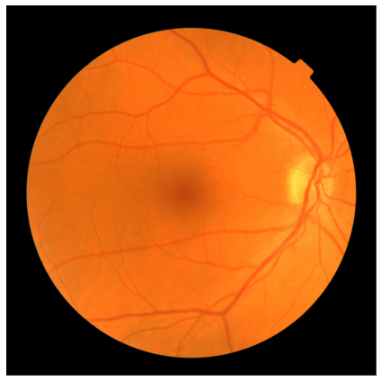

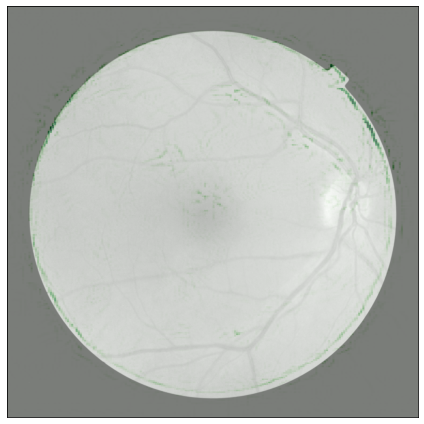

```
0.0 0.56 /blue/ruogu.fang/charlietran/PD_Reproduction/data/Incident_KFold_Data/R1/1/test/HC/1729129_21015_0_0.png
0.0 0.55 /blue/ruogu.fang/charlietran/PD_Reproduction/data/Incident_KFold_Data/R1/1/test/HC/1729129_21016_0_0.png
0.0 0.48 /blue/ruogu.fang/charlietran/PD_Reproduction/data/Incident_KFold_Data/R1/1/test/HC/2167017_21016_0_0.png
0.0 0.53 /blue/ruogu.fang/charlietran/PD_Reproduction/data/Incident_KFold_Data/R1/1/test/HC/3198287_21015_0_0.png
0.0 0.52 /blue/ruogu.fang/charlietran/PD_Reproduction/data/Incident_KFold_Data/R1/1/test/HC/3198287_21016_0_0.png
0.0 0.53 /blue/ruogu.fang/charlietran/PD_Reproduction/data/Incident_KFold_Data/R1/1/test/HC/3391006_21015_0_0.png
0.0 0.54 /blue/ruogu.fang/charlietran/PD_Reproduction/data/Incident_KFold_Data/R1/1/test/HC/3391006_21016_0_0.png
0.0 0.53 /blue/ruogu.fang/charlietran/PD_Reproduction/data/Incident_KFold_Data/R1/1/test/HC/5424494_21015_0_0.png
0.0 0.50 /blue/ruogu.fang/charlietran/PD_Reproduction/data/Incident_KFold_Data/R1/1/test/HC/5424494_21016_0_0.png
0.0 0.51 /blue/ruogu.fang/charlietran/PD_Reproduction/data/Incident_KFold_Data/R1/1/test/HC/5563399_21016_0_0.png
1.0 0.54 /blue/ruogu.fang/charlietran/PD_Reproduction/data/Incident_KFold_Data/R1/1/test/PD/1034220_21015_0_0.png
1.0 0.51 /blue/ruogu.fang/charlietran/PD_Reproduction/data/Incident_KFold_Data/R1/1/test/PD/1034220_21016_0_0.png
1.0 0.50 /blue/ruogu.fang/charlietran/PD_Reproduction/data/Incident_KFold_Data/R1/1/test/PD/1523027_21016_0_0.png
1.0 0.52 /blue/ruogu.fang/charlietran/PD_Reproduction/data/Incident_KFold_Data/R1/1/test/PD/1555296_21016_0_0.png
1.0 0.53 /blue/ruogu.fang/charlietran/PD_Reproduction/data/Incident_KFold_Data/R1/1/test/PD/1562567_21015_0_0.png
1.0 0.52 /blue/ruogu.fang/charlietran/PD_Reproduction/data/Incident_KFold_Data/R1/1/test/PD/1562567_21016_0_0.png
1.0 0.55 /blue/ruogu.fang/charlietran/PD_Reproduction/data/Incident_KFold_Data/R1/1/test/PD/1605541_21015_0_0.png
1.0 0.57 /blue/ruogu.fang/charlietran/PD_Reproduction/data/Incident_KFold_Data/R1/1/test/PD/1605541_21016_0_0.png
1.0 0.56 /blue/ruogu.fang/charlietran/PD_Reproduction/data/Incident_KFold_Data/R1/1/test/PD/1646019_21016_0_0.png
1.0 0.61 /blue/ruogu.fang/charlietran/PD_Reproduction/data/Incident_KFold_Data/R1/1/test/PD/2003452_21016_0_0.png
1.0 0.56 /blue/ruogu.fang/charlietran/PD_Reproduction/data/Incident_KFold_Data/R1/1/test/PD/2950751_21016_0_0.png
1.0 0.5735349655151367
/blue/ruogu.fang/charlietran/PD_Reproduction/data/Incident_KFold_Data/R1/1/test/PD/1605541_21016_0_0.png
```

```python
import torch
from torch.utils.data import DataLoader, ConcatDataset, random_split
import torchvision.datasets as datasets
from torchvision import transforms
import torch.nn as nn
import torch.optim as optim
import os
import torch.backends.cudnn as cudnn
import torchvision.models as models
import numpy as np
os.environ["CUDA_DEVICE_ORDER"] = "PCI_BUS_ID"
os.environ["CUDA_VISIBLE_DEVICES"] = "1"
from sklearn.metrics import classification_report
from torchvision import transforms
from sklearn.metrics import roc_auc_score
from captum.attr import GuidedBackprop
from captum.attr import Saliency
from captum.metrics import sensitivity_max
from captum.metrics import infidelity
from captum.attr import GuidedGradCam
from captum.attr import visualization as viz
from captum.attr import LayerActivation
from captum.attr import NoiseTunnel
from captum.attr import IntegratedGradients
import torch.nn.functional as F
from PIL import Image
import numpy as np


def main():
    normalize = transforms.Normalize(mean=[0.485, 0.456, 0.406],
                                     std=[0.229, 0.224, 0.225])
    test_transform = transforms.Compose([
        transforms.ToTensor(),
        transforms.Resize(256),
        normalize,
    ])

    class ImageFolderWithPaths(datasets.ImageFolder):
        """Custom dataset that includes image file paths. Extends
        torchvision.datasets.ImageFolder
        """

        # override the __getitem__ method. this is the method that dataloader calls
        def __getitem__(self, index):
            # this is what ImageFolder normally returns
            original_tuple = super(ImageFolderWithPaths, self).__getitem__(index)
            # the image file path
            path = self.imgs[index][0]
            # make a new tuple that includes original and the path
            tuple_with_path = (original_tuple + (path,))
            return tuple_with_path


    test = ImageFolderWithPaths(test_path, transform = test_transform)
    test_dataloader = DataLoader(test, batch_size=bsz, shuffle = False)
    model = models.alexnet(pretrained = True)
    model.classifier[6] = nn.Linear(in_features = 4096, out_features = 2)
    checkpoint = torch.load(model_dir)
    model.load_state_dict(checkpoint['model_state_dict'])
    model.eval()
    model = model.cuda()



    def computeAUC(dataGT, dataPRED):
        datanpGT = dataGT.cpu().numpy()
        datanpPRED = dataPRED.cpu().numpy()
        return roc_auc_score(datanpGT, datanpPRED)

    def perturb_fn(inputs):
        noise = torch.tensor(np.random.normal(0, 0.01, inputs.shape)).float().cuda()
        return (noise).cuda(), (inputs - noise).cuda()

    def model_test(model, dataloader):
        model.eval()
        outGT = torch.FloatTensor().cuda()
        outPRED = torch.FloatTensor().cuda()
        outCLASS = torch.FloatTensor().cuda()
        outATTRIBUTION = torch.FloatTensor().cuda()
        outINFIDELITY = torch.FloatTensor().cuda()
        outSENSITIVITY = torch.FloatTensor().cuda()
        attribution_method = GuidedBackprop(model)
        image_volume = torch.FloatTensor().cuda()
        paths_array = []
        with torch.no_grad():
            for i, data in enumerate(dataloader, 0):
                image, labels, paths = data
                image = image.float().cuda()
                image_volume = torch.cat((image_volume, image))
                attribution = attribution_method.attribute(image, target = 1)
                labels = labels.float().cuda()
                output = model(image) # The output current is (N, C) where it is actually (N, 2)
                m = nn.Softmax(dim = 1)
                output_probabilities = m(output)
                class_pred = torch.argmax(output_probabilities, dim = 1)
                # I want to convert
                outPRED = torch.cat((outPRED, output_probabilities), 0)
                outGT = torch.cat((outGT, labels), 0)
                outCLASS = torch.cat((outCLASS, class_pred), 0)
                outATTRIBUTION = torch.cat((outATTRIBUTION, attribution))
                paths_array.append(paths)
        return outPRED, outCLASS, outGT, outATTRIBUTION, image_volume, paths_array[0]

#
    outPRED, outCLASS, outGT, outATTRIBUTION,  image_volume, paths_array = model_test(model, test_dataloader)
    return outPRED, outCLASS, outGT, outATTRIBUTION, image_volume, paths_array

if __name__ == '__main__':
    counter = 0
    test_path = '/blue/ruogu.fang/charlietran/PD_Reproduction/data/Incident_KFold_Data/R1/1/test/'
    model_dir = '/blue/ruogu.fang/charlietran/PD_Reproduction/models/overall/alexnet/alexnetweights_3_1.pth'
    bsz = 64
    outPRED, outCLASS, outGT, outATTRIBUTION, image_volume, paths_array = main()
    counter += 1

    model_name = 'alexnet'
    base_folder = '/blue/ruogu.fang/charlietran/PD_Reproduction/'
    experiment_tag = 'overall'

    # The index here is the index of the ordered list of images in the folder. So you can choose which image to see
    index = - 4

    attribution_map = outATTRIBUTION[index].unsqueeze(dim = 0)
    upsample_map = F.interpolate(attribution_map, (1536, 2048))
    upsample_map = upsample_map.squeeze().cpu().detach().numpy().transpose(1,2,0)
    upsample_map = upsample_map[:, int((2048 - 1536)/2): int((2048 + 1536)/2 ), :]
    print(upsample_map.shape)

    im = np.array(Image.open('/blue/ruogu.fang/charlietran/PD_Project/code/incident_sample.png'))
    im = im[:, int((2048 - 1536)/2): int((2048 + 1536)/2 ), :]
    im = np.array(im)


    _ = viz.visualize_image_attr_multiple(upsample_map,
                                  im,
                                  ['original_image'],
                                  ["all"],
                                  show_colorbar=False,
                                  use_pyplot = True)



    _ = viz.visualize_image_attr_multiple(upsample_map,
                                  im,
                                  ['blended_heat_map'],
                                  ["positive"],
                                  show_colorbar=False,
                                  use_pyplot = True)

    for j in range(len(outGT)):
        print(outGT[j].item(), '{:.2f}'.format(outPRED[j][1].item()), paths_array[j])

    print(outGT[index].item(), outPRED[index][1].item())
    print(paths_array[index])
```

# 7. Plot the results here

### Note: There may be some confusion between googlenet and inceptionv1 naming throughout. They're the same thing - just different names used for the same thing. I used inceptionv1 throughout my original implementaions but may have changed the name while coding as the other.

# I will create a zip file for my own original results. You should have your own results without zipping assuming that all of the models have been run.

```python
os.chdir('/blue/ruogu.fang/charlietran/PD_Reproduction/')
!unzip results.zip

# You're also free to cp this resuls from my folder

#cp '/blue/ruogu.fang/charlietran/PD_Reproduction/results.zip' -d 'your folder'
```

[output not shown]

[output cut: 289 more lines]

[output not shown]

# Accuracy Plot

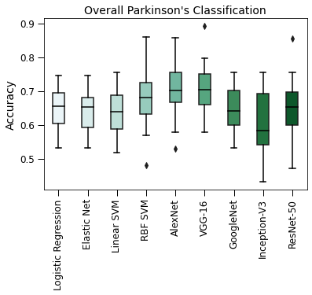

```python
import seaborn as sns

base_folder = '/blue/ruogu.fang/charlietran/PD_Reproduction/results/'
experiment_tag = 'overall'


font = {'fontname':'Arial'}

logistic_regression = np.load(os.path.join(base_folder,
                                           experiment_tag,
                                           'logistic_regression',
                                           'logistic_regression_accuracy_scores.npy'), allow_pickle = True).tolist()
elastic_net = np.load(os.path.join(base_folder,
                                           experiment_tag,
                                           'elastic_net',
                                           'elastic_net_accuracy_scores.npy'), allow_pickle = True).tolist()
svm_linear = np.load(os.path.join(base_folder,
                                           experiment_tag,
                                           'svm_linear',
                                           'svm_linear_accuracy_scores.npy'), allow_pickle = True).tolist()
svm_rbf = np.load(os.path.join(base_folder,
                                           experiment_tag,
                                           'svm_rbf',
                                           'svm_rbf_accuracy_scores.npy'), allow_pickle = True).tolist()
alexnet = np.load(os.path.join(base_folder,
                                           experiment_tag,
                                           'alexnet',
                                           'alexnet_accuracy_scores.npy'), allow_pickle = True).tolist()


vgg = np.load(os.path.join(base_folder,
                                           experiment_tag,
                                           'vgg',
                                           'vgg_accuracy_scores.npy'), allow_pickle = True).tolist()

googlenet = np.load(os.path.join(base_folder,
                                           experiment_tag,
                                           'googlenet',
                                           'inceptionv1_accuracy_scores.npy'), allow_pickle = True).tolist()

inceptionv3 = np.load(os.path.join(base_folder,
                                           experiment_tag,
                                           'inceptionv3',
                                           'inceptionv3_accuracy_scores.npy'), allow_pickle = True).tolist()

resnet = np.load(os.path.join(base_folder,
                                           experiment_tag,
                                           'resnet',
                                           'resnet_accuracy_scores.npy'), allow_pickle = True).tolist()



model_names = ['Logistic Regression', 'Elastic Net', 'Linear SVM', 'RBF SVM', 'AlexNet', 'VGG-16', 'GoogleNet', 'InceptionV3', 'ResNet-50']
scores = [logistic_regression, elastic_net, svm_linear, svm_rbf, alexnet, vgg, googlenet, inceptionv3, resnet]

dataset = pd.DataFrame()
dataset['Logistic Regression'] = scores[0]
dataset['Elastic Net'] = scores[1]
dataset['Linear SVM'] = scores[2]
dataset['RBF SVM'] = scores[3]
dataset['AlexNet'] = scores[4]
dataset['VGG-16'] = scores[5]
dataset['GoogleNet'] = scores[6]
dataset['Inception-V3'] = scores[7]
dataset['ResNet-50'] = scores[8]


ax = sns.boxplot(data=dataset, width = 0.4, palette = 'BuGn')
#sns.set_style("whitegrid")
for line in ax.get_lines():
    line.set_color('black')

ax.set_xticklabels(ax.get_xticklabels(), rotation=90, ha="right", fontsize = 13, **font)
ax.set_ylabel('Accuracy', fontsize = 14, **font)
for label in ax.get_xticklabels():
    label.set_horizontalalignment('center')
ax.xaxis.set_tick_params(width=1, length = 8)
ax.yaxis.set_tick_params(width=1, length = 8)
ax.tick_params(axis='both', which='major', labelsize=12)
ax.tick_params(axis='both', which='minor', labelsize=12)

plt.title("Overall Parkinson's Classification", fontsize = 14)
```

## AUC Plot

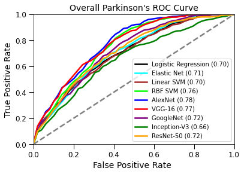

```python
import numpy as np
from sklearn import metrics

base_folder = '/blue/ruogu.fang/charlietran/PD_Reproduction/results/'
experiment_tag = 'overall'


font = {'fontname':'Arial'}

logistic_regression_prob = np.load(os.path.join(base_folder,
                                           experiment_tag,
                                           'logistic_regression',
                                           'logistic_regression_pd_probability.npy'), allow_pickle = True).tolist()
elastic_net_prob = np.load(os.path.join(base_folder,
                                           experiment_tag,
                                           'elastic_net',
                                           'elastic_net_pd_probability.npy'), allow_pickle = True).tolist()
svm_linear_prob = np.load(os.path.join(base_folder,
                                           experiment_tag,
                                           'svm_linear',
                                           'svm_linear_pd_probability.npy'), allow_pickle = True).tolist()
svm_rbf_prob = np.load(os.path.join(base_folder,
                                           experiment_tag,
                                           'svm_rbf',
                                           'svm_rbf_pd_probability.npy'), allow_pickle = True).tolist()
alexnet_prob = np.load(os.path.join(base_folder,
                                           experiment_tag,
                                           'alexnet',
                                           'alexnet_pd_probability.npy'), allow_pickle = True).tolist()


vgg_prob = np.load(os.path.join(base_folder,
                                           experiment_tag,
                                           'vgg',
                                           'vgg_pd_probability.npy'), allow_pickle = True).tolist()

googlenet_prob = np.load(os.path.join(base_folder,
                                           experiment_tag,
                                           'googlenet',
                                           'inceptionv1_pd_probability.npy'), allow_pickle = True).tolist()

inceptionv3_prob = np.load(os.path.join(base_folder,
                                           experiment_tag,
                                           'inceptionv3',
                                           'inceptionv3_pd_probability.npy'), allow_pickle = True).tolist()

resnet_prob = np.load(os.path.join(base_folder,
                                           experiment_tag,
                                           'resnet',
                                           'resnet_pd_probability.npy'), allow_pickle = True).tolist()

######################################################################################################
######################################################################################################
######################################################################################################

logistic_regression_GT = np.load(os.path.join(base_folder,
                                           experiment_tag,
                                           'logistic_regression',
                                           'logistic_regression_ground_truth.npy'), allow_pickle = True).tolist()
elastic_net_GT = np.load(os.path.join(base_folder,
                                           experiment_tag,
                                           'elastic_net',
                                           'elastic_net_ground_truth.npy'), allow_pickle = True).tolist()
svm_linear_GT = np.load(os.path.join(base_folder,
                                           experiment_tag,
                                           'svm_linear',
                                           'svm_linear_ground_truth.npy'), allow_pickle = True).tolist()
svm_rbf_GT = np.load(os.path.join(base_folder,
                                           experiment_tag,
                                           'svm_rbf',
                                           'svm_rbf_ground_truth.npy'), allow_pickle = True).tolist()
alexnet_GT = np.load(os.path.join(base_folder,
                                           experiment_tag,
                                           'alexnet',
                                           'alexnet_ground_truth.npy'), allow_pickle = True).tolist()


vgg_GT = np.load(os.path.join(base_folder,
                                           experiment_tag,
                                           'vgg',
                                           'vgg_ground_truth.npy'), allow_pickle = True).tolist()

googlenet_GT = np.load(os.path.join(base_folder,
                                           experiment_tag,
                                           'googlenet',
                                           'inceptionv1_ground_truth.npy'), allow_pickle = True).tolist()

inceptionv3_GT = np.load(os.path.join(base_folder,
                                           experiment_tag,
                                           'inceptionv3',
                                           'inceptionv3_ground_truth.npy'), allow_pickle = True).tolist()

resnet_GT = np.load(os.path.join(base_folder,
                                           experiment_tag,
                                           'resnet',
                                           'resnet_ground_truth.npy'), allow_pickle = True).tolist()


def curve_generation(model_GT, model_pred):
    fpr_mean    = np.linspace(0, 1, 50)
    interp_tprs = []
    for i in range(25):
        fpr, tpr, _ = metrics.roc_curve(model_GT[i], model_pred[i])
        interp_tpr    = np.interp(fpr_mean, fpr, tpr)
        interp_tpr[0] = 0.0
        interp_tprs.append(interp_tpr)
    tpr_mean     = np.mean(interp_tprs, axis=0)
    tpr_mean[-1] = 1.0
    tpr_std      = 1.96*np.std(interp_tprs, axis=0) / np.sqrt(25)
    tpr_upper    = np.clip(tpr_mean+tpr_std, 0, 1)
    tpr_lower    = np.clip(tpr_mean-tpr_std, 0, 1)

    return fpr_mean, tpr_mean, tpr_upper, tpr_lower


logistic_regression_fpr_mean, logistic_regression_tpr_mean, logistic_regression_tpr_upper, logistic_regression_tpr_lower = curve_generation(logistic_regression_GT, logistic_regression_prob)
elastic_net_fpr_mean, elastic_net_tpr_mean, elastic_net_tpr_upper, elastic_net_tpr_lower = curve_generation(elastic_net_GT, elastic_net_prob)
svm_linear_fpr_mean, svm_linear_tpr_mean, svm_linear_tpr_upper, svm_linear_tpr_lower = curve_generation(svm_linear_GT, svm_linear_prob)
svm_rbf_fpr_mean, svm_rbf_tpr_mean, svm_rbf_tpr_upper, svm_rbf_tpr_lower = curve_generation(svm_rbf_GT, svm_rbf_prob)
alexnet_fpr_mean, alexnet_tpr_mean, alexnet_tpr_upper, alexnet_tpr_lower = curve_generation(alexnet_GT, alexnet_prob)
vgg_fpr_mean, vgg_tpr_mean, vgg_tpr_upper, vgg_tpr_lower = curve_generation(vgg_GT, vgg_prob)
googlenet_fpr_mean, googlenet_tpr_mean,googlenet_tpr_upper, googlenet_tpr_lower = curve_generation(googlenet_GT, googlenet_prob)
inceptionv3_fpr_mean, inceptionv3_tpr_mean,inceptionv3_tpr_upper, inceptionv3_tpr_lower = curve_generation(inceptionv3_GT, inceptionv3_prob)
resnet_fpr_mean, resnet_tpr_mean, resnet_tpr_upper, resnet_tpr_lower = curve_generation(resnet_GT, resnet_prob)

font = {'fontname':'Arial'}
plt.plot(logistic_regression_fpr_mean, logistic_regression_tpr_mean, color = 'black', linewidth = 2.5)
plt.plot(elastic_net_fpr_mean, elastic_net_tpr_mean, color = 'aqua', linewidth = 2.5)
plt.plot(svm_linear_fpr_mean, svm_linear_tpr_mean, color = 'brown', linewidth = 2.5)
plt.plot(svm_rbf_fpr_mean, svm_rbf_tpr_mean, color = 'lime', linewidth = 2.5)
plt.plot(alexnet_fpr_mean, alexnet_tpr_mean, color = 'b', linewidth = 2.5)
plt.plot(vgg_fpr_mean, vgg_tpr_mean, color = 'red', linewidth = 2.5)
plt.plot(googlenet_fpr_mean, googlenet_tpr_mean, color = 'purple', linewidth = 2.5)
plt.plot(inceptionv3_fpr_mean, inceptionv3_tpr_mean, color = 'g', linewidth = 2.5)
plt.plot(resnet_fpr_mean, resnet_tpr_mean, color = 'orange', linewidth = 2.5)

x_points = [0, 1]
y_points = [0, 1]

plt.legend(['Logistic Regression (0.70)', 'Elastic Net (0.71)', 'Linear SVM (0.70)', 'RBF SVM (0.76)', 'AlexNet (0.78)', 'VGG-16 (0.77)', 'GoogleNet (0.72)', 'Inception-V3 (0.66)', 'ResNet-50 (0.72)'], fontsize = 10)

plt.plot(x_points, y_points, linestyle='dashed', color = 'gray', linewidth = 2.5)
plt.xlim([0,1])
plt.ylim([0,1])
plt.xlabel('False Positive Rate ', fontsize = 14, **font)
plt.ylabel('True Positive Rate', fontsize = 14, **font)

plt.tick_params(axis='both', which='major', length = 8, labelsize = 12, width = 1)



plt.title("Overall Parkinson's ROC Curve", fontsize = 14, **font)



plt.show()
```

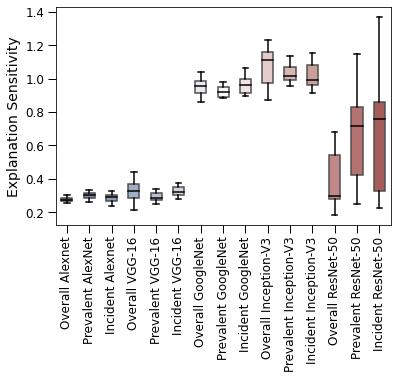

```python
base_folder = '/blue/ruogu.fang/charlietran/PD_Reproduction/results/'
experiment_tag = 'overall'
font = {'fontname':'Arial'}

##############################################################################################################
##############################################################################################################
##############################################################################################################

alexnet_overall_sens = np.load(os.path.join(base_folder,
                                           'overall',
                                           'alexnet',
                                           'alexnet_XAIsensitivity.npy'), allow_pickle = True).tolist()


vgg_overall_sens = np.load(os.path.join(base_folder,
                                           'overall',
                                           'vgg',
                                           'vgg_XAIsensitivity.npy'), allow_pickle = True).tolist()

googlenet_overall_sens = np.load(os.path.join(base_folder,
                                           'overall',
                                           'googlenet',
                                           'inceptionv1_XAIsensitivity.npy'), allow_pickle = True).tolist()

inceptionv3_overall_sens = np.load(os.path.join(base_folder,
                                           'overall',
                                           'inceptionv3',
                                           'inceptionv3_XAIsensitivity.npy'), allow_pickle = True).tolist()

resnet_overall_sens = np.load(os.path.join(base_folder,
                                           'overall',
                                           'resnet',
                                           'resnet_XAIsensitivity.npy'), allow_pickle = True).tolist()
##############################################################################################################
##############################################################################################################
##############################################################################################################

##############################################################################################################
##############################################################################################################
##############################################################################################################

alexnet_prev_sens = np.load(os.path.join(base_folder,
                                           'prevalent',
                                           'alexnet',
                                           'alexnet_XAIsensitivity.npy'), allow_pickle = True).tolist()


vgg_prev_sens = np.load(os.path.join(base_folder,
                                           'prevalent',
                                           'vgg',
                                           'vgg_XAIsensitivity.npy'), allow_pickle = True).tolist()

googlenet_prev_sens = np.load(os.path.join(base_folder,
                                           'prevalent',
                                           'googlenet',
                                           'inceptionv1_XAIsensitivity.npy'), allow_pickle = True).tolist()

inceptionv3_prev_sens = np.load(os.path.join(base_folder,
                                           'prevalent',
                                           'inceptionv3',
                                           'inceptionv3_XAIsensitivity.npy'), allow_pickle = True).tolist()

resnet_prev_sens = np.load(os.path.join(base_folder,
                                           'prevalent',
                                           'resnet',
                                           'resnet_XAIsensitivity.npy'), allow_pickle = True).tolist()

##############################################################################################################
##############################################################################################################
##############################################################################################################

alexnet_inc_sens = np.load(os.path.join(base_folder,
                                           'incident',
                                           'alexnet',
                                           'alexnet_XAIsensitivity.npy'), allow_pickle = True).tolist()


vgg_inc_sens = np.load(os.path.join(base_folder,
                                           'incident',
                                           'vgg',
                                           'vgg_XAIsensitivity.npy'), allow_pickle = True).tolist()

googlenet_inc_sens = np.load(os.path.join(base_folder,
                                           'incident',
                                           'googlenet',
                                           'inceptionv1_XAIsensitivity.npy'), allow_pickle = True).tolist()

inceptionv3_inc_sens = np.load(os.path.join(base_folder,
                                           'incident',
                                           'inceptionv3',
                                           'inceptionv3_XAIsensitivity.npy'), allow_pickle = True).tolist()

resnet_inc_sens = np.load(os.path.join(base_folder,
                                           'incident',
                                           'resnet',
                                           'resnet_XAIsensitivity.npy'), allow_pickle = True).tolist()

dataset = pd.DataFrame()
dataset['Overall Alexnet'] = alexnet_overall_sens
dataset['Prevalent AlexNet'] = alexnet_prev_sens
dataset['Incident Alexnet'] = alexnet_inc_sens
dataset['Overall VGG-16'] = vgg_overall_sens
dataset['Prevalent VGG-16'] = vgg_prev_sens
dataset['Incident VGG-16'] = vgg_inc_sens
dataset['Overall GoogleNet'] = googlenet_overall_sens
dataset['Prevalent GoogleNet'] = googlenet_prev_sens
dataset['Incident GoogleNet'] = googlenet_inc_sens
dataset['Overall Inception-V3'] = inceptionv3_overall_sens
dataset['Prevalent Inception-V3'] = inceptionv3_prev_sens
dataset['Incident Inception-V3'] = inceptionv3_inc_sens
dataset['Overall ResNet-50'] = resnet_overall_sens
dataset['Prevalent ResNet-50'] = resnet_prev_sens
dataset['Incident ResNet-50'] = resnet_inc_sens



ax = sns.boxplot(data=dataset, width = 0.5, palette = 'vlag', showfliers = False, whis = 1.0)
for line in ax.get_lines():
  line.set_color('black')

ax.set_xticklabels(ax.get_xticklabels(), rotation=90, ha="right", fontsize = 13)
ax.set_ylabel('Explanation Sensitivity', fontsize = 14)
for label in ax.get_xticklabels():
    label.set_horizontalalignment('center')
ax.xaxis.set_tick_params(width=1, length = 8)
ax.yaxis.set_tick_params(width=1, length = 8)
ax.tick_params(axis='both', which='major', labelsize=12)
ax.tick_params(axis='both', which='minor', labelsize=12)
```

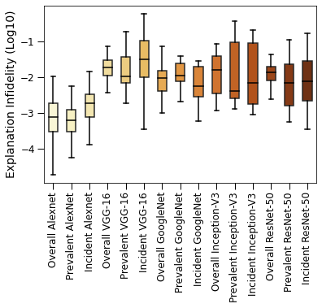

```python
base_folder = '/blue/ruogu.fang/charlietran/PD_Reproduction/results/'
experiment_tag = 'overall'
font = {'fontname':'Arial'}

##############################################################################################################
##############################################################################################################
##############################################################################################################

alexnet_overall_infid = np.log10(np.load(os.path.join(base_folder,
                                           'overall',
                                           'alexnet',
                                           'alexnet_XAIinfidelity.npy'), allow_pickle = True)).tolist()


vgg_overall_infid = np.log10(np.load(os.path.join(base_folder,
                                           'overall',
                                           'vgg',
                                           'vgg_XAIinfidelity.npy'), allow_pickle = True)).tolist()

googlenet_overall_infid = np.log10(np.load(os.path.join(base_folder,
                                           'overall',
                                           'googlenet',
                                           'inceptionv1_XAIinfidelity.npy'), allow_pickle = True)).tolist()

inceptionv3_overall_infid = np.log10(np.load(os.path.join(base_folder,
                                           'overall',
                                           'inceptionv3',
                                           'inceptionv3_XAIinfidelity.npy'), allow_pickle = True)).tolist()

resnet_overall_infid = np.log10(np.load(os.path.join(base_folder,
                                           'overall',
                                           'resnet',
                                           'resnet_XAIinfidelity.npy'), allow_pickle = True)).tolist()
##############################################################################################################
##############################################################################################################
##############################################################################################################

##############################################################################################################
##############################################################################################################
##############################################################################################################

alexnet_prev_infid = np.log10(np.load(os.path.join(base_folder,
                                           'prevalent',
                                           'alexnet',
                                           'alexnet_XAIinfidelity.npy'), allow_pickle = True)).tolist()


vgg_prev_infid = np.log10(np.load(os.path.join(base_folder,
                                           'prevalent',
                                           'vgg',
                                           'vgg_XAIinfidelity.npy'), allow_pickle = True)).tolist()

googlenet_prev_infid = np.log10(np.load(os.path.join(base_folder,
                                           'prevalent',
                                           'googlenet',
                                           'inceptionv1_XAIinfidelity.npy'), allow_pickle = True)).tolist()

inceptionv3_prev_infid = np.log10(np.load(os.path.join(base_folder,
                                           'prevalent',
                                           'inceptionv3',
                                           'inceptionv3_XAIinfidelity.npy'), allow_pickle = True)).tolist()

resnet_prev_infid = np.log10(np.load(os.path.join(base_folder,
                                           'prevalent',
                                           'resnet',
                                           'resnet_XAIinfidelity.npy'), allow_pickle = True)).tolist()

##############################################################################################################
##############################################################################################################
##############################################################################################################

alexnet_inc_infid = np.log10(np.load(os.path.join(base_folder,
                                           'incident',
                                           'alexnet',
                                           'alexnet_XAIinfidelity.npy'), allow_pickle = True)).tolist()


vgg_inc_infid = np.log10(np.load(os.path.join(base_folder,
                                           'incident',
                                           'vgg',
                                           'vgg_XAIinfidelity.npy'), allow_pickle = True)).tolist()

googlenet_inc_infid = np.log10(np.load(os.path.join(base_folder,
                                           'incident',
                                           'googlenet',
                                           'inceptionv1_XAIinfidelity.npy'), allow_pickle = True)).tolist()

inceptionv3_inc_infid = np.log10(np.load(os.path.join(base_folder,
                                           'incident',
                                           'inceptionv3',
                                           'inceptionv3_XAIinfidelity.npy'), allow_pickle = True)).tolist()

resnet_inc_infid = np.log10(np.load(os.path.join(base_folder,
                                           'incident',
                                           'resnet',
                                           'resnet_XAIinfidelity.npy'), allow_pickle = True)).tolist()

dataset = pd.DataFrame()
dataset['Overall Alexnet'] = alexnet_overall_infid
dataset['Prevalent AlexNet'] = alexnet_prev_infid
dataset['Incident Alexnet'] = alexnet_inc_infid
dataset['Overall VGG-16'] = vgg_overall_infid
dataset['Prevalent VGG-16'] = vgg_prev_infid
dataset['Incident VGG-16'] = vgg_inc_infid
dataset['Overall GoogleNet'] = googlenet_overall_infid
dataset['Prevalent GoogleNet'] = googlenet_prev_infid
dataset['Incident GoogleNet'] = googlenet_inc_infid
dataset['Overall Inception-V3'] = inceptionv3_overall_infid
dataset['Prevalent Inception-V3'] = inceptionv3_prev_infid
dataset['Incident Inception-V3'] = inceptionv3_inc_infid
dataset['Overall ResNet-50'] = resnet_overall_infid
dataset['Prevalent ResNet-50'] = resnet_prev_infid
dataset['Incident ResNet-50'] = resnet_inc_infid



ax = sns.boxplot(data=dataset, width = 0.5, palette = "YlOrBr", showfliers = False)
for line in ax.get_lines():
    line.set_color('black')

ax.set_xticklabels(ax.get_xticklabels(), rotation=90, ha="right", fontsize = 13)
ax.set_ylabel('Explanation Infidelity (Log10)', fontsize = 14)
for label in ax.get_xticklabels():
    label.set_horizontalalignment('center')
ax.xaxis.set_tick_params(width=1, length = 8)
ax.yaxis.set_tick_params(width=1, length = 8)
ax.tick_params(axis='both', which='major', labelsize=12)
ax.tick_params(axis='both', which='minor', labelsize=12)
```

```python
!jupyter nbconvert --to html project_code.ipynb -d '/blue/ruogu.fang/charlietran/PD_code.ipynb'
```

[output not shown]

[output cut: 101 more lines]

[output not shown]